# Test a Perceptual Phenomenon

### Analyzing the Stroop Effect

Perform the analysis in the space below. Remember to follow [the instructions](https://docs.google.com/document/d/1-OkpZLjG_kX9J6LIQ5IltsqMzVWjh36QpnP2RYpVdPU/pub?embedded=True) and review the [project rubric](https://review.udacity.com/#!/rubrics/71/view) before submitting. Once you've completed the analysis and write-up, download this file as a PDF or HTML file, upload that PDF/HTML into the workspace here (click on the orange Jupyter icon in the upper left then Upload), then use the Submit Project button at the bottom of this page. This will create a zip file containing both this .ipynb doc and the PDF/HTML doc that will be submitted for your project.

(1) What is the independent variable? What is the dependent variable?

**Independent Variable:** The Category of the word being congruent word or not.  
**Dependent Variable:** Time taken to recognize the color measured for the both of congruent/incongruent words. I take time as the dependent variable because I believe that time taken can be affected by whether the word is congruent or not.

(2) What is an appropriate set of hypotheses for this task? Specify your null and alternative hypotheses, and clearly define any notation used. Justify your choices.

**Null Hypothesis:** The average time $\mu$ taken is the same irrespective to whether the word is congruent or not
$$ H_0: \mu_0 >= \mu_a $$
**Alternative Hypothesis:** The average time taken to recognise incongruent colored text $\mu_a$ is **more than** that taken for congruent words $\mu_0$
$$ H_a: \mu_0 < \mu_a $$

> Since the same person is tested for both congruent and incongruent words, the test is **dependent**. And I will conduct **t-test**

(3) Report some descriptive statistics regarding this dataset. Include at least one measure of central tendency and at least one measure of variability. The name of the data file is 'stroopdata.csv'.

```python
import pandas as pd
import numpy as np
import matplotlib.pyplot as plt

time_df = pd.read_csv('stroopdata.csv')
time_df.head()
```

|  | Congruent | Incongruent |
| --- | --- | --- |
| 0 | 12.079 | 19.278 |
| 1 | 16.791 | 18.741 |
| 2 | 9.564 | 21.214 |
| 3 | 8.630 | 15.687 |
| 4 | 14.669 | 22.803 |

```python
time_df.shape
```

```
(24, 2)
```

```python
time_df.info()
```

```
<class 'pandas.core.frame.DataFrame'>
RangeIndex: 24 entries, 0 to 23
Data columns (total 2 columns):
Congruent      24 non-null float64
Incongruent    24 non-null float64
dtypes: float64(2)
memory usage: 464.0 bytes
```

```python
time_df.isnull().any()
```

```
Congruent      False
Incongruent    False
dtype: bool
```

```python
time_df.describe()
```

|  | Congruent | Incongruent |
| --- | --- | --- |
| count | 24.000000 | 24.000000 |
| mean | 14.051125 | 22.015917 |
| std | 3.559358 | 4.797057 |
| min | 8.630000 | 15.687000 |
| 25% | 11.895250 | 18.716750 |
| 50% | 14.356500 | 21.017500 |
| 75% | 16.200750 | 24.051500 |
| max | 22.328000 | 35.255000 |

> **Notes:**
> - From the **Congruent** and **Incongruent** means, it's clear that more time is taken for **Incongruent** group color recognition.
> - Even with applying one standard deviation to the means to estimate the bulk of the data [17.2.4, 26.8] for Incongruent data and [10.4, 17.6] It's clear that incongruent text takes more time.
> - Actually, in all 5 number summary, the **Incongruent** time seemes to be longer than the **Congruent** which are in favor of the alternative hypothesis, yet, these indication are not significant as it's just a sample of the test and should be tested for its significance to represent the population.

(4) Provide one or two visualizations that show the distribution of the sample data. Write one or two sentences noting what you observe about the plot or plots.

```python
def sytle_plot_spines(*axes, right = True, left = False, top = True, bottom = False):
    """
    takes axes object and apply my favorite style to the plot axes
    """
    for ax in axes:
        if top:
            ax.spines['top'].set_visible(False)
        if right:
            ax.spines['right'].set_visible(False)
        if bottom:
            ax.spines['bottom'].set_visible(False)
        if left:
            ax.spines['left'].set_visible(False)
```

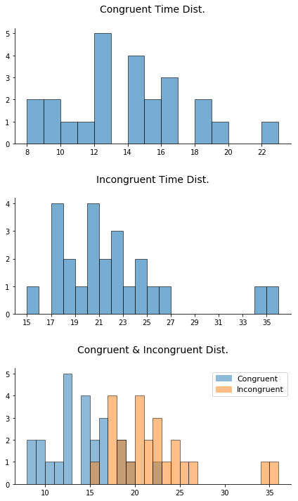

```python
import matplotlib.patches as mpatches

fig = plt.figure(figsize = (6, 10))

# fig.suptitle('\n\nDistributions of Congruent and Incongruent Test Times\n', fontsize = 15);

ax1 = plt.subplot(311)

plt.hist(time_df['Congruent'],
         bins = range(8, 24),
         alpha = .6,
         edgecolor = 'black',
        )
plt.title('Congruent Time Dist.\n', fontsize = 14)

ax2 = plt.subplot(312)
plt.hist(time_df['Incongruent'],
         bins = range(15, 37),
         alpha = .6,
         edgecolor = 'black'
        )

plt.title('\nIncongruent Time Dist.\n', fontsize = 14)
plt.xticks(range(15, 36, 2), range(15, 36, 2))
plt.yticks(range(5), range(5))

ax3 = plt.subplot(313)
plt.hist(time_df['Congruent'],
         bins = range(8, 37),
         alpha = .5,
         edgecolor = 'black',
        )

plt.hist(time_df['Incongruent'],
         bins = range(8, 37),
         alpha = .5,
         edgecolor = 'black'
        );

sytle_plot_spines(ax1, ax2, ax3)

non_sponsored = mpatches.Patch(color='#8EBAD9', label='Congruent')
sponsored = mpatches.Patch(color ='#FFBE86', label = 'Incongruent')
plt.legend(handles=[non_sponsored, sponsored], fontsize = 11)

plt.title('\nCongruent & Incongruent Dist.\n', fontsize = 14);
plt.tight_layout();
```

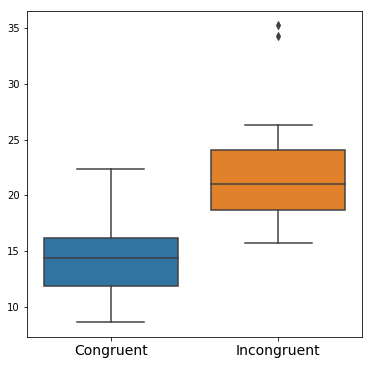

```python
import seaborn as sns

plt.figure(figsize=(6,6))
ax = plt.subplot(111)
g = sns.boxplot(data = time_df)

plt.xticks(fontsize = 14)
# g.set(ylim = (0, 65))
# ax.set_facecolor('#efeded')
plt.show()
```

```python
## Getting the values of the seemingly outliers in the Incongruent group

sorted(time_df['Incongruent'])[-2:]
```

```
[34.288000000000004, 35.255]
```

```python
## Measuring the mean of the Incongruent group without the outliers

np.mean(sorted(time_df['Incongruent'])[:-2])
```

```
20.85631818181818
```

(5) Now, perform the statistical test and report your results. What is your confidence level or Type I error associated with your test? What is your conclusion regarding the hypotheses you set up? Did the results match up with your expectations? **Hint:** Think about what is being measured on each individual, and what statistic best captures how an individual reacts in each environment.

Since we testing the mean difference of two samples. I will conduct t-test and I will not assume equality of variances of the populations as there is no indication can be made just from the samples. And below are three approaches to test, one using built-in library, one manual and the final test is by bootstrapping before assuming a t-test, simulating the sampling distribution, then calculating the p-value and t-statistic

I will consider the mean difference as the statistic, and consider a 95% confidency interval one sided test, in other words with no more than a 5% Type I Error tolerance